# Project NLP Depression (Manuscript Results Analyses)

Jihyun Hur

2024-05-11

## Results

1. Positive and negative human sentiment Spearman correlation

```r
## Study 1
cor.test(study1_data$avg_human_tone_pos_mean, study1_data$avg_human_tone_neg_mean, method="spearman")
```

```
##
##  Spearman's rank correlation rho
##
## data:  study1_data$avg_human_tone_pos_mean and study1_data$avg_human_tone_neg_mean
## S = 1816290, p-value < 2.2e-16
## alternative hypothesis: true rho is not equal to 0
## sample estimates:
##        rho
## -0.9001628
```

```r
## Study 2
cor.test(study2_data$avg_human_tone_pos_mean, study2_data$avg_human_tone_neg_mean, method="spearman")
```

```
##
##  Spearman's rank correlation rho
##
## data:  study2_data$avg_human_tone_pos_mean and study2_data$avg_human_tone_neg_mean
## S = 7630136, p-value < 2.2e-16
## alternative hypothesis: true rho is not equal to 0
## sample estimates:
##        rho
## -0.9165108
```

2. Human sentiment score ~ PHQ-9 at baseline

```r
## Study 1
cor.test(study1_data$phq, study1_data$avg_human_tone_mean_diff, method="spearman")
```

```
##
##  Spearman's rank correlation rho
##
## data:  study1_data$phq and study1_data$avg_human_tone_mean_diff
## S = 1590671, p-value < 2.2e-16
## alternative hypothesis: true rho is not equal to 0
## sample estimates:
##        rho
## -0.6641254
```

```r
## Study 2
cor.test(study2_data$phq, study2_data$avg_human_tone_mean_diff, method="spearman")
```

```
##
##  Spearman's rank correlation rho
##
## data:  study2_data$phq and study2_data$avg_human_tone_mean_diff
## S = 6279972, p-value < 2.2e-16
## alternative hypothesis: true rho is not equal to 0
## sample estimates:
##        rho
## -0.5773814
```

3. Human sentiment score ~ PHQ-9 at follow-up

```r
## Study 1
cor.test(study1_data$phq_2, study1_data$avg_human_tone_mean_diff, method="spearman")
```

```
##
##  Spearman's rank correlation rho
##
## data:  study1_data$phq_2 and study1_data$avg_human_tone_mean_diff
## S = 1539404, p-value < 2.2e-16
## alternative hypothesis: true rho is not equal to 0
## sample estimates:
##        rho
## -0.6104911
```

```r
## Study 2
cor.test(study2_data$phq_2, study2_data$avg_human_tone_mean_diff, method="spearman")
```

```
##
##  Spearman's rank correlation rho
##
## data:  study2_data$phq_2 and study2_data$avg_human_tone_mean_diff
## S = 6353445, p-value < 2.2e-16
## alternative hypothesis: true rho is not equal to 0
## sample estimates:
##       rho
## -0.595836
```

4. PHQ-9 at baseline ~ PHQ-9 at follow-up

```r
## Study 1
cor.test(study1_data$phq, study1_data$phq_2)
```

```
##
##  Pearson's product-moment correlation
##
## data:  study1_data$phq and study1_data$phq_2
## t = 16.413, df = 177, p-value < 2.2e-16
## alternative hypothesis: true correlation is not equal to 0
## 95 percent confidence interval:
##  0.7111967 0.8290457
## sample estimates:
##       cor
## 0.7768351
```

```r
## Study 2
cor.test(study2_data$phq, study2_data$phq_2)
```

```
##
##  Pearson's product-moment correlation
##
## data:  study2_data$phq and study2_data$phq_2
## t = 25.119, df = 286, p-value < 2.2e-16
## alternative hypothesis: true correlation is not equal to 0
## 95 percent confidence interval:
##  0.7896438 0.8624118
## sample estimates:
##       cor
## 0.8295162
```

5-1. Robust regression testing prediction using human sentiment score

```r
pi <- c(`(Intercept)` = "Intercept",
        phq = "Initial PHQ-9 score",
        avg_human_tone_mean_diff = "Human sentiment score",
        avg_human_tone_pos_mean = "Human positivity score",
        avg_human_tone_neg_mean = "Human negativity score",
        gpt_tone_mean_diff = "ChatGPT sentiment score",
        gpt_tone_pos_mean = "ChatGPT positivity score",
        gpt_tone_neg_mean = "ChatGPT negativity score",
        liwc_tone_mean_diff = "LIWC sentiment score",
        liwc_tone_pos_mean = "LIWC positivity score",
        liwc_tone_neg_mean = "LIWC negativity score",
        base_hap = "Baseline mood")

terms_use <- c("phq", "avg_human_tone_mean_diff", "avg_human_tone_pos_mean", "avg_human_tone_neg_mean",
               "gpt_tone_mean_diff", "gpt_tone_pos_mean", "gpt_tone_neg_mean",
               "liwc_tone_mean_diff", "liwc_tone_pos_mean", "liwc_tone_neg_mean")

## Study 1
ms5_study1_mod <- lmrob(phq_2   ~  phq + age + gender + edu +  avg_human_tone_mean_diff, data=study1_data,  control = lmrob.control(setting = "KS2014", k.max=2000))

tab_model(ms5_study1_mod,  terms = terms_use,
          show.ci = FALSE, show.se = TRUE,
             pred.labels = pi, dv.labels = c(""), string.pred = "Coeffcient",
            show.stat = "TRUE", string.est = "Beta estimates", string.stat = "T-stat",
            string.se = "SE", string.p = "P")
```

| Coeffcient | Beta estimates | SE | T-stat | P |
| --- | --- | --- | --- | --- |
| Initial PHQ-9 score | 0.64 | 0.05 | 12.15 | **<0.001** |
| Human sentiment score | -0.26 | 0.09 | -3.11 | **0.002** |
| Observations | 178 |  |  |  |
| R<sup>2</sup> / R<sup>2</sup> adjusted | 0.739 / 0.717 |  |  |  |

```r
# f^2 calculation
# model without sentiment score
ms5_study1_mod2<-lmrob(phq_2   ~  phq  + age + gender + edu, data=study1_data,  control = lmrob.control(setting = "KS2014", k.max=2000))
s1_mod_f <- (summary(ms5_study1_mod)$r.squared - summary(ms5_study1_mod2)$r.squared)/(1-summary(ms5_study1_mod)$r.squared)
sprintf('Study 1 regression model Cohen f^2 = %.3f', s1_mod_f)
```

```
## [1] "Study 1 regression model Cohen f^2 = 0.051"
```

```r
# Wald test
anova(ms5_study1_mod, ms5_study1_mod2, test='Wald')
```

```
## Robust Wald Test Table
##
## Model 1: phq_2 ~ phq + age + gender + edu + avg_human_tone_mean_diff
## Model 2: phq_2 ~ phq + age + gender + edu
## Largest model fitted by lmrob(), i.e. SMDM
##
##   pseudoDf Test.Stat Df Pr(>chisq)
## 1      163
## 2      164    9.6469  1   0.001897 **
## ---
## Signif. codes:  0 '***' 0.001 '**' 0.01 '*' 0.05 '.' 0.1 ' ' 1
```

```r
## Study 2
ms5_study2_mod <- lmrob(phq_2   ~  phq + age + gender + edu +  avg_human_tone_mean_diff, data=study2_data,  control = lmrob.control(setting = "KS2014", k.max=2000))

tab_model(ms5_study2_mod,  terms = terms_use,
          show.ci = FALSE, show.se = TRUE,
             pred.labels = pi, dv.labels = c(""), string.pred = "Coeffcient",
            show.stat = "TRUE", string.est = "Beta estimates", string.stat = "T-stat",
            string.se = "SE", string.p = "P")
```

| Coeffcient | Beta estimates | SE | T-stat | P |
| --- | --- | --- | --- | --- |
| Initial PHQ-9 score | 0.85 | 0.04 | 21.35 | **<0.001** |
| Human sentiment score | -0.19 | 0.06 | -3.07 | **0.002** |
| Observations | 286 |  |  |  |
| R<sup>2</sup> / R<sup>2</sup> adjusted | 0.796 / 0.785 |  |  |  |

```r
# f^2 calculation
# model without sentiment score
ms5_study2_mod2<-lmrob(phq_2   ~  phq  + age + gender + edu, data=study2_data,  control = lmrob.control(setting = "KS2014", k.max=2000))
s2_mod_f <- (summary(ms5_study2_mod)$r.squared - summary(ms5_study2_mod2)$r.squared)/(1-summary(ms5_study2_mod)$r.squared)
sprintf('Study 2 regression model Cohen f^2 = %.3f', s2_mod_f)
```

```
## [1] "Study 2 regression model Cohen f^2 = 0.018"
```

```r
# Wald test
anova(ms5_study2_mod, ms5_study2_mod2, test='Wald')
```

```
## Robust Wald Test Table
##
## Model 1: phq_2 ~ phq + age + gender + edu + avg_human_tone_mean_diff
## Model 2: phq_2 ~ phq + age + gender + edu
## Largest model fitted by lmrob(), i.e. SMDM
##
##   pseudoDf Test.Stat Df Pr(>chisq)
## 1      270
## 2      271    9.4103  1   0.002158 **
## ---
## Signif. codes:  0 '***' 0.001 '**' 0.01 '*' 0.05 '.' 0.1 ' ' 1
```

5-2. Robust regression results human sentiment plots (Fig. 1A)

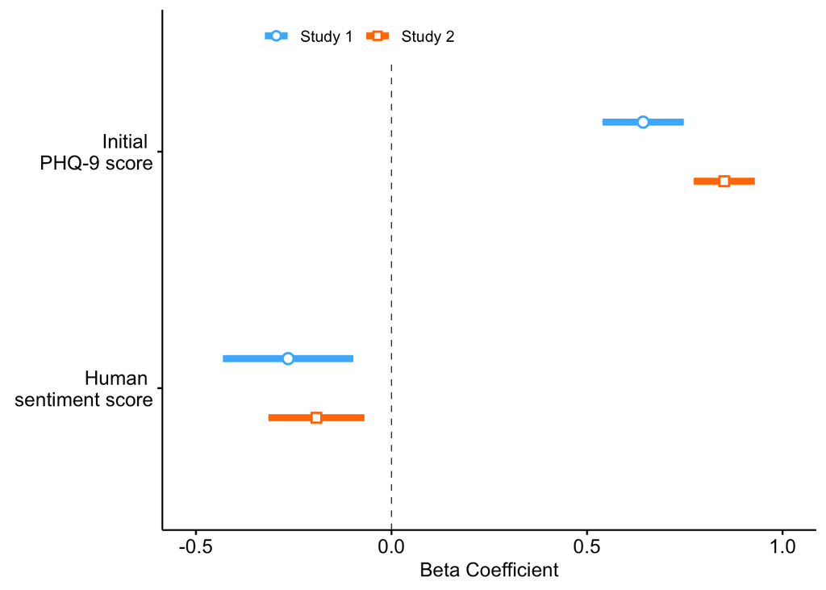

```r
reg_mod <- plot_summs(ms5_study1_mod, ms5_study2_mod, scale=FALSE, inner_ci_level = .95,  plot.distributions = FALSE,
                 rescale.distributions = TRUE,   # = c("age", "gender"),
                 coefs = c(
                   "Initial \nPHQ-9 score" = 'phq',
                   "Human \nsentiment score" = "avg_human_tone_mean_diff"),
                 model.names=c('Study 1', 'Study 2')) + scale_x_continuous(limits = c(-0.51, 1.01),
                                                                           breaks=c(-0.50, 0.00, 0.50, 1.00))
fig_1a <- ggpar(reg_mod, xlab = 'Beta Coefficient',
            font.y = 0,
            ggtheme = theme_pubr()) + theme(legend.title = element_blank(), legend.position = c(0.3,0.95),
                                            legend.direction = "horizontal")
fig_1a
```

6-1. LOOCV prediction (Study 1)

6-2. LOOCV prediction (Study 2)

6-3. LOOCV results and plot (Fig. 1B)

```
## [1] "Study 1 LOOCV MSE = 8.34"
```

```
## [1] "Study 1 Pred ~ Actual R = 0.53 (P = 0.000)"
```

```
## [1] "Study 2 LOOCV MSE = 9.59"
```

```
## [1] "Study 2 Pred ~ Actual R = 0.32 (P = 0.000)"
```

[output not shown]

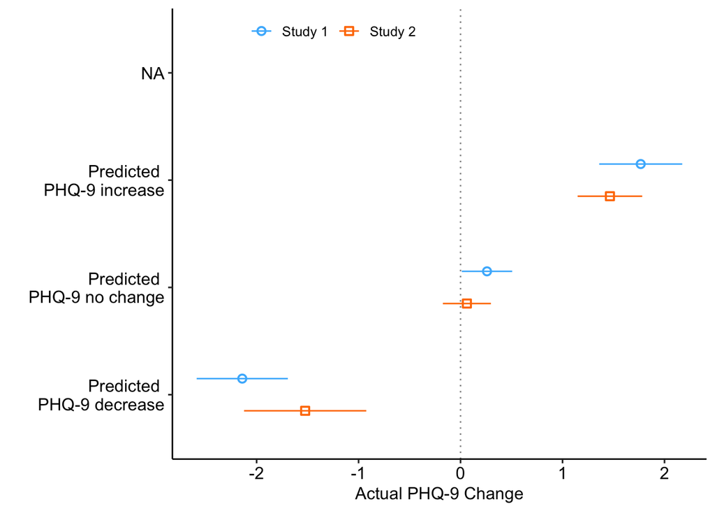

6-4. Robust Mixed Linear Effect

```r
# MIXED EFFECT
low_phq_lmer <- rlmer(phq_2   ~  phq + age + gender + edu + avg_human_tone_mean_diff + (1 |study_num), data = dat %>% filter(phq<=5))
```

```
## boundary (singular) fit: see help('isSingular')
```

```r
summary(low_phq_lmer)
```

```
## Robust linear mixed model fit by DAStau
## Formula: phq_2 ~ phq + age + gender + edu + avg_human_tone_mean_diff +      (1 | study_num)
##    Data: dat %>% filter(phq <= 5)
##
## Scaled residuals:
##     Min      1Q  Median      3Q     Max
## -2.4592 -0.6323 -0.0597  0.5469  8.9534
##
## Random effects:
##  Groups    Name        Variance Std.Dev.
##  study_num (Intercept) 0.000    0.000
##  Residual              2.946    1.716
## Number of obs: 250, groups: study_num, 2
##
## Fixed effects:
##                                     Estimate Std. Error t value
## (Intercept)                         3.955426   1.091932   3.622
## phq                                 0.679495   0.073014   9.306
## age                                -0.006960   0.007999  -0.870
## genderMale                         -0.366761   0.236434  -1.551
## genderPrefer not to say            -1.154309   1.798283  -0.642
## eduAssociate degree (occupational) -2.214415   1.007842  -2.197
## eduBachelors                       -1.919348   0.926781  -2.071
## eduDoctoral                        -2.697277   1.150787  -2.344
## eduGED or equivalent               -2.454894   1.013189  -2.423
## eduHigh school graduate            -2.307435   0.962824  -2.397
## eduMasters                         -1.678134   0.954295  -1.759
## eduNo high school diploma          -2.960236   1.558736  -1.899
## eduProfessional school             -1.986977   1.164453  -1.706
## eduSome college (no degree)        -2.104459   0.943930  -2.229
## avg_human_tone_mean_diff           -0.141635   0.049439  -2.865
##
## Correlation of Fixed Effects:
##             (Intr) phq    age    gndrMl gnPnts edAd() edBchl edDctr eGEDoe
## phq         -0.415
## age         -0.426  0.182
## genderMale  -0.166 -0.014 -0.018
## gndrPrfrnts -0.068  0.091  0.071  0.087
## edAd(ccptn) -0.790  0.190 -0.003  0.048  0.017
## eduBachelrs -0.893  0.193  0.084  0.113  0.029  0.875
```

[output cut: 24 more lines]

```
## Robustness weights for the residuals:
##  202 weights are ~= 1. The remaining 48 ones are summarized as
##    Min. 1st Qu.  Median    Mean 3rd Qu.    Max.
##   0.150   0.530   0.706   0.663   0.866   0.998
##
## Robustness weights for the random effects:
## [1] 1 1
##
## Rho functions used for fitting:
##   Residuals:
##     eff: smoothed Huber (k = 1.345, s = 10)
##     sig: smoothed Huber, Proposal 2 (k = 1.345, s = 10)
##   Random Effects, variance component 1 (study_num):
##     eff: smoothed Huber (k = 1.345, s = 10)
##     vcp: smoothed Huber, Proposal 2 (k = 1.345, s = 10)
```

```r
tab_model(low_phq_lmer, show.se = "TRUE", show.stat = "TRUE", string.est = "Beta estimates", string.stat = "T-stat", string.se = "SE", string.p = "P")
```

|  | phq_2 |  |  |  |  |
| --- | --- | --- | --- | --- | --- |
| Predictors | Beta estimates | SE | CI | T-stat | P |
| (Intercept) | 3.96 | 1.09 | 1.82 – 6.10 | 3.62 | **<0.001** |
| phq | 0.68 | 0.07 | 0.54 – 0.82 | 9.31 | **<0.001** |
| age | -0.01 | 0.01 | -0.02 – 0.01 | -0.87 | 0.384 |
| gender [Male] | -0.37 | 0.24 | -0.83 – 0.10 | -1.55 | 0.121 |
| gender [Prefer not to say] | -1.15 | 1.80 | -4.68 – 2.37 | -0.64 | 0.521 |
| edu [Associate degree (occupational)] | -2.21 | 1.01 | -4.19 – -0.24 | -2.20 | **0.028** |
| edu [Bachelors] | -1.92 | 0.93 | -3.74 – -0.10 | -2.07 | **0.038** |
| edu [Doctoral] | -2.70 | 1.15 | -4.95 – -0.44 | -2.34 | **0.019** |
| edu [GED or equivalent] | -2.45 | 1.01 | -4.44 – -0.47 | -2.42 | **0.015** |
| edu [High school graduate] | -2.31 | 0.96 | -4.19 – -0.42 | -2.40 | **0.017** |
| edu [Masters] | -1.68 | 0.95 | -3.55 – 0.19 | -1.76 | 0.079 |
| edu [No high school diploma] | -2.96 | 1.56 | -6.02 – 0.09 | -1.90 | 0.058 |
| edu [Professional school] | -1.99 | 1.16 | -4.27 – 0.30 | -1.71 | 0.088 |
| edu [Some college (no degree)] | -2.10 | 0.94 | -3.95 – -0.25 | -2.23 | **0.026** |
| avg human tone mean diff | -0.14 | 0.05 | -0.24 – -0.04 | -2.86 | **0.004** |
| Random Effects |  |  |  |  |  |
| σ<sup>2</sup> | 2.95 |  |  |  |  |
| τ<sub>00</sub> <sub>study_num</sub> | 0.00 |  |  |  |  |
| ICC | 0.00 |  |  |  |  |
| N <sub>study_num</sub> | 2 |  |  |  |  |
| Observations | 250 |  |  |  |  |
| Marginal R<sup>2</sup> / Conditional R<sup>2</sup> | 0.421 / 0.421 |  |  |  |  |

```r
high_phq_lmer <- rlmer(phq_2   ~  phq + age + gender + edu +  avg_human_tone_mean_diff + (1 |study_num), data = dat %>% filter(phq>5))
summary(high_phq_lmer)
```

```
## Robust linear mixed model fit by DAStau
## Formula: phq_2 ~ phq + age + gender + edu + avg_human_tone_mean_diff +      (1 | study_num)
##    Data: dat %>% filter(phq > 5)
##
## Scaled residuals:
##     Min      1Q  Median      3Q     Max
## -4.1444 -0.6437  0.0105  0.6580  2.8249
##
## Random effects:
##  Groups    Name        Variance Std.Dev.
##  study_num (Intercept)  1.023   1.011
##  Residual              11.453   3.384
## Number of obs: 214, groups: study_num, 2
##
## Fixed effects:
##                                    Estimate Std. Error t value
## (Intercept)                         5.46166    2.01845   2.706
## phq                                 0.71020    0.06526  10.883
## age                                -0.04079    0.02015  -2.024
## genderMale                         -0.32526    0.51198  -0.635
## genderOthers                        2.02153    1.80075   1.123
## eduAssociate degree (occupational) -1.33583    1.70009  -0.786
## eduBachelors                       -1.50546    1.49859  -1.005
## eduDoctoral                        -2.12936    2.18148  -0.976
## eduGED or equivalent                0.72304    2.50110   0.289
## eduHigh school graduate            -1.39839    1.56792  -0.892
## eduMasters                         -3.26756    1.57739  -2.071
## eduNo high school diploma          -1.80050    2.55520  -0.705
## eduProfessional school             -1.06912    2.12264  -0.504
## eduSome college (no degree)        -1.04562    1.57763  -0.663
## avg_human_tone_mean_diff           -0.32265    0.09966  -3.238
##
## Correlation of Fixed Effects:
##             (Intr) phq    age    gndrMl gndrOt edAd() edBchl edDctr eGEDoe
## phq         -0.488
## age         -0.500  0.339
## genderMale   0.004 -0.103  0.064
## genderOthrs -0.064  0.034  0.138  0.127
## edAd(ccptn) -0.572  0.010 -0.055 -0.193 -0.030
## eduBachelrs -0.701  0.080  0.015 -0.153 -0.031  0.822
```

[output cut: 24 more lines]

```
## Robustness weights for the residuals:
##  172 weights are ~= 1. The remaining 42 ones are summarized as
##    Min. 1st Qu.  Median    Mean 3rd Qu.    Max.
##   0.325   0.644   0.811   0.761   0.920   0.998
##
## Robustness weights for the random effects:
## [1] 1 1
##
## Rho functions used for fitting:
##   Residuals:
##     eff: smoothed Huber (k = 1.345, s = 10)
##     sig: smoothed Huber, Proposal 2 (k = 1.345, s = 10)
##   Random Effects, variance component 1 (study_num):
##     eff: smoothed Huber (k = 1.345, s = 10)
##     vcp: smoothed Huber, Proposal 2 (k = 1.345, s = 10)
```

```r
tab_model(high_phq_lmer, show.se = "TRUE", show.stat = "TRUE", string.est = "Beta estimates", string.stat = "T-stat", string.se = "SE", string.p = "P")
```

|  | phq_2 |  |  |  |  |
| --- | --- | --- | --- | --- | --- |
| Predictors | Beta estimates | SE | CI | T-stat | P |
| (Intercept) | 5.46 | 2.02 | 1.51 – 9.42 | 2.71 | **0.007** |
| phq | 0.71 | 0.07 | 0.58 – 0.84 | 10.88 | **<0.001** |
| age | -0.04 | 0.02 | -0.08 – -0.00 | -2.02 | **0.043** |
| gender [Male] | -0.33 | 0.51 | -1.33 – 0.68 | -0.64 | 0.525 |
| gender [Others] | 2.02 | 1.80 | -1.51 – 5.55 | 1.12 | 0.262 |
| edu [Associate degree (occupational)] | -1.34 | 1.70 | -4.67 – 2.00 | -0.79 | 0.432 |
| edu [Bachelors] | -1.51 | 1.50 | -4.44 – 1.43 | -1.00 | 0.315 |
| edu [Doctoral] | -2.13 | 2.18 | -6.40 – 2.15 | -0.98 | 0.329 |
| edu [GED or equivalent] | 0.72 | 2.50 | -4.18 – 5.63 | 0.29 | 0.773 |
| edu [High school graduate] | -1.40 | 1.57 | -4.47 – 1.67 | -0.89 | 0.372 |
| edu [Masters] | -3.27 | 1.58 | -6.36 – -0.18 | -2.07 | **0.038** |
| edu [No high school diploma] | -1.80 | 2.56 | -6.81 – 3.21 | -0.70 | 0.481 |
| edu [Professional school] | -1.07 | 2.12 | -5.23 – 3.09 | -0.50 | 0.614 |
| edu [Some college (no degree)] | -1.05 | 1.58 | -4.14 – 2.05 | -0.66 | 0.507 |
| avg human tone mean diff | -0.32 | 0.10 | -0.52 – -0.13 | -3.24 | **0.001** |
| Random Effects |  |  |  |  |  |
| σ<sup>2</sup> | 11.45 |  |  |  |  |
| τ<sub>00</sub> <sub>study_num</sub> | 1.02 |  |  |  |  |
| ICC | 0.08 |  |  |  |  |
| N <sub>study_num</sub> | 2 |  |  |  |  |
| Observations | 214 |  |  |  |  |
| Marginal R<sup>2</sup> / Conditional R<sup>2</sup> | 0.543 / 0.581 |  |  |  |  |

[figure not shown]

```r
lmer_plot <- plot_summs(low_phq_lmer, high_phq_lmer, scale=FALSE, inner_ci_level = .95,  plot.distributions = FALSE,
                 rescale.distributions = FALSE,
                 coefs = c(
                   "Initial \nPHQ-9 score" = 'phq',
                   "Human sentiment score" = "avg_human_tone_mean_diff"),
                 model.names=c('Minimal PHQ-9 (PHQ-9<5)', 'Mild-to-moderate PHQ-9 (PHQ-9>=5)')) + scale_x_continuous(limits = c(-0.55, 1.01), breaks=c(-0.50, 0.00, 0.50, 1.00))

lmer_plot <- ggpar(lmer_plot, xlab = 'Beta Coefficient',
            font.y = 0, ggtheme = theme_pubr()) + theme(legend.title = element_blank(), legend.position = c(0.3,0.95), legend.direction = "horizontal")

lmer_plot
```

```r
ggsave(filename = file.path(dir_save, "fig_s6.pdf"), plot=lmer_plot, width=6.5, height=3.5, units="in", dpi=600)
```

7. Linguistic distance ~ PHQ

```r
## Study 1
cor.test(study1_data$liwc_ling_dist, study1_data$phq, method="spearman")
```

```
##
##  Spearman's rank correlation rho
##
## data:  study1_data$liwc_ling_dist and study1_data$phq
## S = 1495228, p-value = 0.02842
## alternative hypothesis: true rho is not equal to 0
## sample estimates:
##        rho
## -0.1557776
```

```r
# Study 2
cor.test(study2_data$liwc_ling_dist, study2_data$phq, method="spearman")
```

```
##
##  Spearman's rank correlation rho
##
## data:  study2_data$liwc_ling_dist and study2_data$phq
## S = 6144038, p-value = 0.04028
## alternative hypothesis: true rho is not equal to 0
## sample estimates:
##        rho
## -0.1145363
```

8. Correlation between human and ChatGPT (GPT-3.5) sentiment

```r
## Study 1
cor.test(study1_data$avg_human_tone_mean_diff, study1_data$gpt_tone_mean_diff, method="spearman")
```

```
##
##  Spearman's rank correlation rho
##
## data:  study1_data$avg_human_tone_mean_diff and study1_data$gpt_tone_mean_diff
## S = 41187, p-value < 2.2e-16
## alternative hypothesis: true rho is not equal to 0
## sample estimates:
##      rho
## 0.956911
```

```r
## Study 2
cor.test(study2_data$avg_human_tone_mean_diff, study2_data$gpt_tone_mean_diff, method="spearman")
```

```
##
##  Spearman's rank correlation rho
##
## data:  study2_data$avg_human_tone_mean_diff and study2_data$gpt_tone_mean_diff
## S = 177945, p-value < 2.2e-16
## alternative hypothesis: true rho is not equal to 0
## sample estimates:
##       rho
## 0.9553045
```

9. Correlation between PHQ-9 and ChatGPT (GPT-3.5) sentiment

```r
## Study 1
cor.test(study1_data$phq, study1_data$gpt_tone_mean_diff, method="spearman")
```

```
##
##  Spearman's rank correlation rho
##
## data:  study1_data$phq and study1_data$gpt_tone_mean_diff
## S = 1604344, p-value < 2.2e-16
## alternative hypothesis: true rho is not equal to 0
## sample estimates:
##      rho
## -0.67843
```

```r
## Study 2
cor.test(study2_data$phq, study2_data$gpt_tone_mean_diff, method="spearman")
```

```
##
##  Spearman's rank correlation rho
##
## data:  study2_data$phq and study2_data$gpt_tone_mean_diff
## S = 6319550, p-value < 2.2e-16
## alternative hypothesis: true rho is not equal to 0
## sample estimates:
##        rho
## -0.5873225
```

10-1. Robust regression testing prediction using ChatGPT sentiment score

| Coeffcient | Beta estimates | SE | T-stat | P |
| --- | --- | --- | --- | --- |
| Initial PHQ-9 score | 0.67 | 0.05 | 12.56 | **<0.001** |
| ChatGPT sentiment score | -0.21 | 0.08 | -2.50 | **0.013** |
| Observations | 178 |  |  |  |
| R<sup>2</sup> / R<sup>2</sup> adjusted | 0.736 / 0.713 |  |  |  |

```
## [1] "Study 1 regression model Cohen f^2 = 0.038"
```

| Coeffcient | Beta estimates | SE | T-stat | P |
| --- | --- | --- | --- | --- |
| Initial PHQ-9 score | 0.85 | 0.04 | 21.42 | **<0.001** |
| ChatGPT sentiment score | -0.18 | 0.06 | -2.99 | **0.003** |
| Observations | 286 |  |  |  |
| R<sup>2</sup> / R<sup>2</sup> adjusted | 0.796 / 0.785 |  |  |  |

```
## [1] "Study 2 regression model Cohen f^2 = 0.018"
```

10-2. Robust regression ChatGPT sentiment score plot (Fig. 2A)

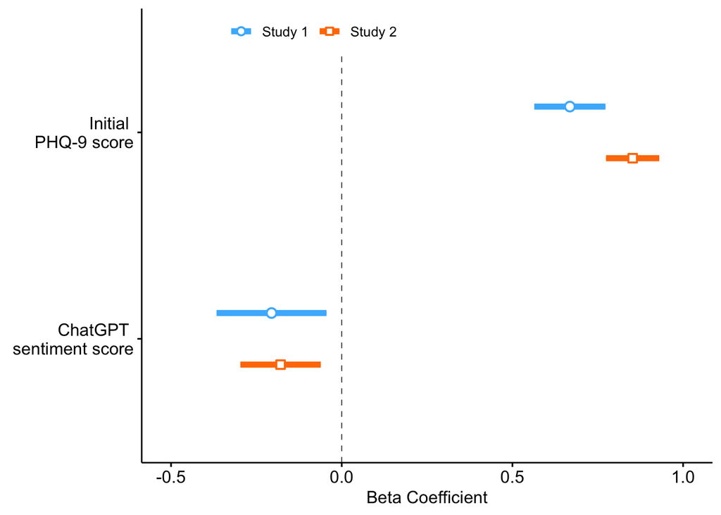

```r
gpt_reg_mod <- plot_summs(ms10_study1_mod, ms10_study2_mod, scale=FALSE, inner_ci_level = .95,  plot.distributions = FALSE,
                 rescale.distributions = TRUE,
                 coefs = c(
                   "Initial \nPHQ-9 score" = 'phq',
                   "ChatGPT \nsentiment score" = "gpt_tone_mean_diff"),
                 model.names=c('Study 1', 'Study 2')) + scale_x_continuous(limits = c(-0.51, 1.01),
                                                                           breaks=c(-0.50, 0.00, 0.50, 1.00))
fig_2a <- ggpar(gpt_reg_mod, xlab = 'Beta Coefficient',
            font.y = 0,
            ggtheme = theme_pubr()) + theme(legend.title = element_blank(), legend.position = c(0.3,0.95),
                                            legend.direction = "horizontal")
fig_2a
```

11. LIWC ~ Human sentiment score

```r
## Study 1
cor.test(study1_data$liwc_tone_mean_diff, study1_data$avg_human_tone_mean_diff, method="spearman")
```

```
##
##  Spearman's rank correlation rho
##
## data:  study1_data$liwc_tone_mean_diff and study1_data$avg_human_tone_mean_diff
## S = 240937, p-value < 2.2e-16
## alternative hypothesis: true rho is not equal to 0
## sample estimates:
##       rho
## 0.7479373
```

```r
## Study 2
cor.test(study2_data$liwc_tone_mean_diff, study2_data$avg_human_tone_mean_diff, method="spearman")
```

```
##
##  Spearman's rank correlation rho
##
## data:  study2_data$liwc_tone_mean_diff and study2_data$avg_human_tone_mean_diff
## S = 1152915, p-value < 2.2e-16
## alternative hypothesis: true rho is not equal to 0
## sample estimates:
##       rho
## 0.7104149
```

12. LIWC ~ GPT sentiment score

```r
## Study 1
cor.test(study1_data$liwc_tone_mean_diff, study1_data$gpt_tone_mean_diff, method="spearman")
```

```
##
##  Spearman's rank correlation rho
##
## data:  study1_data$liwc_tone_mean_diff and study1_data$gpt_tone_mean_diff
## S = 232863, p-value < 2.2e-16
## alternative hypothesis: true rho is not equal to 0
## sample estimates:
##       rho
## 0.7563838
```

```r
## Study 2
cor.test(study2_data$liwc_tone_mean_diff, study2_data$gpt_tone_mean_diff, method="spearman")
```

```
##
##  Spearman's rank correlation rho
##
## data:  study2_data$liwc_tone_mean_diff and study2_data$gpt_tone_mean_diff
## S = 1066541, p-value < 2.2e-16
## alternative hypothesis: true rho is not equal to 0
## sample estimates:
##     rho
## 0.73211
```

13. LIWC ~ PHQ-9 at baseline

```r
## Study 1
cor.test(study1_data$liwc_tone_mean_diff, study1_data$phq, method="spearman")
```

```
##
##  Spearman's rank correlation rho
##
## data:  study1_data$liwc_tone_mean_diff and study1_data$phq
## S = 2001125, p-value = 2.095e-15
## alternative hypothesis: true rho is not equal to 0
## sample estimates:
##        rho
## -0.5236217
```

```r
## Study 2
cor.test(study2_data$liwc_tone_mean_diff, study2_data$phq, method="spearman")
```

```
##
##  Spearman's rank correlation rho
##
## data:  study2_data$liwc_tone_mean_diff and study2_data$phq
## S = 8103158, p-value < 2.2e-16
## alternative hypothesis: true rho is not equal to 0
## sample estimates:
##        rho
## -0.4699234
```

14-1. Robust regression testing prediction using LIWC sentiment score

| Coeffcient | Beta estimates | SE | T-stat | P |
| --- | --- | --- | --- | --- |
| Initial PHQ-9 score | 0.76 | 0.05 | 16.84 | **<0.001** |
| LIWC sentiment score | 0.02 | 0.06 | 0.34 | 0.734 |
| Observations | 178 |  |  |  |
| R<sup>2</sup> / R<sup>2</sup> adjusted | 0.724 / 0.700 |  |  |  |

```
## [1] "Study 1 regression model Cohen f^2 = -0.005"
```

| Coeffcient | Beta estimates | SE | T-stat | P |
| --- | --- | --- | --- | --- |
| Initial PHQ-9 score | 0.91 | 0.04 | 25.75 | **<0.001** |
| LIWC sentiment score | -0.04 | 0.06 | -0.66 | 0.511 |
| Observations | 286 |  |  |  |
| R<sup>2</sup> / R<sup>2</sup> adjusted | 0.792 / 0.780 |  |  |  |

```
## [1] "Study 2 regression model Cohen f^2 = -0.002"
```

[figure not shown]

```r
liwc_reg_mod <- plot_summs(ms14_study1_mod, ms14_study2_mod, scale=FALSE, inner_ci_level = .95,  plot.distributions = FALSE,
                 rescale.distributions = TRUE,
                 coefs = c(
                   "Initial \nPHQ-9 score" = 'phq',
                   "LIWC \nsentiment score" = "tone_mean_diff"),
                 model.names=c('Study 1', 'Study 2')) + scale_x_continuous(limits = c(-0.51, 1.01),
                                                                           breaks=c(-0.50, 0.00, 0.50, 1.00))
fig_2b <- ggpar(liwc_reg_mod, xlab = 'Beta Coefficient',
            font.y = 0,
            ggtheme = theme_pubr()) + theme(legend.title = element_blank(), legend.position = c(0.3,0.95),
                                            legend.direction = "horizontal")
fig_2b
```

```r
fig_2 <- ggarrange(fig_2a, fig_2b, ncol = 2, nrow = 1, labels = c("A", "B"))
ggsave(filename = file.path(dir_save, "fig_2.pdf"), plot=fig_2, width=7, height=3.5, units="in", dpi=700)
```

15. Baseline mood ~ human sentiment score

```r
## Study 1
cor.test(study1_data$base_hap, study1_data$avg_human_tone_mean_diff, method="spearman")
```

```
##
##  Spearman's rank correlation rho
##
## data:  study1_data$base_hap and study1_data$avg_human_tone_mean_diff
## S = 576905, p-value = 3.933e-08
## alternative hypothesis: true rho is not equal to 0
## sample estimates:
##       rho
## 0.3964548
```

```r
## Study 2
cor.test(study2_data$base_hap, study2_data$avg_human_tone_mean_diff, method="spearman")
```

```
##
##  Spearman's rank correlation rho
##
## data:  study2_data$base_hap and study2_data$avg_human_tone_mean_diff
## S = 2972057, p-value = 1.334e-05
## alternative hypothesis: true rho is not equal to 0
## sample estimates:
##       rho
## 0.2534891
```

16. RPE ~ human sentiment score

```r
## Study 1
cor.test(study1_data$rpe, study1_data$avg_human_tone_mean_diff, method="spearman")
```

```
##
##  Spearman's rank correlation rho
##
## data:  study1_data$rpe and study1_data$avg_human_tone_mean_diff
## S = 1029444, p-value = 0.3057
## alternative hypothesis: true rho is not equal to 0
## sample estimates:
##         rho
## -0.07698175
```

```r
## Study 2
cor.test(study2_data$rpe, study2_data$avg_human_tone_mean_diff, method="spearman")
```

```
##
##  Spearman's rank correlation rho
##
## data:  study2_data$rpe and study2_data$avg_human_tone_mean_diff
## S = 3997714, p-value = 0.9443
## alternative hypothesis: true rho is not equal to 0
## sample estimates:
##          rho
## -0.004131745
```

```r
# Study 2 happiness data
# mat_file <- "real_v2_happydata.mat"
#
# # Load the .mat file
# data <- readMat(file.path(dat_dir, mat_file))
#
# # Access the structure of structures
# main_struct <- data$datatosave
# nrow <- dim(data$datatosave)[2]
# df_list <- list()
#
# # Iterate through the rows
# for (i in 1:nrow) {
#   # Access the 1x1 struct for each row
#   sub_struct <- main_struct[[i]]
#
#   # Access and print the variables you need
#   variable1 <- sub_struct[[1]] # rawhappy
#   variable2 <- sub_struct[[12]] # Replace "variable2_name" with the actual variable name
#
#   tmp_df <- data.frame(subjID = i, rawhappy = variable1, predhappy = variable2)
#   df_list[[i]] <- tmp_df
# }
#
# final_df2 <- do.call(rbind, df_list)
# long_data2 <- final_df2 %>%
#   gather(name, value, -subjID)
# long_data2 <- long_data2 %>% group_by(subjID, name) %>% mutate(data_point = row_number())
#
# # subject ID = 7 r2
# subj_id = 220
#
# data$datatosave[[subj_id]][[13]]
#
# study2_r2 <- format(round(data$datatosave[[subj_id]][[13]], 2), nsmall = 2)
#
# all2_r2 <- NULL
#
# for (i in 1:length(data$datatosave)) {
#   #print(i)
#   all2_r2[i] <- data$datatosave[[i]][[13]]
# }
#
# median(all2_r2)
#
# # phq
# data_fin$phq[subj_id]
# data_fin$diag_dep[subj_id]
#
# fig_3a <- ggplot(long_data2 %>% filter(subjID == subj_id), aes(x = data_point, y=value, group=name, linetype=name, shape=name, colour=name)) +
#   geom_line(size = 1) + ylim(c(0,100)) +
#   geom_point(size = 3) + theme_pubr() + xlab('Rating Number') + ylab('Happiness Rating') +
#   scale_linetype_manual(values = c("rawhappy" = "solid", "predhappy" = "solid"), labels = c("rawhappy" = "Raw Happiness", "predhappy" = "Predicted Happiness")) +
#   scale_shape_manual( values = c("rawhappy" = 16, "predhappy" = 17), labels = c("rawhappy" = "Raw Happiness", "predhappy" = "Predicted Happiness")) +
#   scale_color_manual(values = c("rawhappy" = "blue", "predhappy" = "red"), labels = c("rawhappy" = "Raw Happiness", "predhappy" = "Predicted Happiness")) + theme(legend.text=element_text(size=14), legend.position = c(0.375,0.85), legend.title = element_blank(),
#         text = element_text(size = 14), axis.title = element_text(size = 16))
#
# fig_3a
#
# # Fig 3b
#
# # current mood (baseline happiness) by binned PHQ-9
# fig_3b <- study1_2_data %>%
#   group_by(Group = cut(phq, breaks = c(-Inf, 4, 9, 14, 19, +Inf),
#                        labels = c("0-4", "5-9", "10-14","15-19", "20+"))) %>%
#   summarise(mean_basehap = mean(base_hap), sem_basehap = sd(base_hap) / sqrt(n())) %>%
#
#   # Create the bar plot
#   ggplot() +
#   geom_point(aes(x = Group, y = mean_basehap, fill = Group), stat = "identity", size=1.5,
#              position = position_dodge(width = 0.4), width = 1) + geom_hline(yintercept=50, alpha=0.5) +
#   geom_errorbar(aes(x = Group, ymin = mean_basehap - sem_basehap, ymax = mean_basehap + sem_basehap), size = 1,
#                 position = position_dodge(width = 2), width = 0.2) +
#   # Customize plot aesthetics
#   labs(x = "Initial PHQ-9 Score",
#        y = "Baseline Mood Parameter") +
#   theme_pubr() + ylim(c(0,100)) + theme(legend.position="none", text = element_text(size = 14), axis.title = element_text(size = 16))
#
# fig_3b
#
# fig_3 <- ggarrange(fig_3a, fig_3b, ncol=2, labels = c("A", "B"))
# ggsave(filename = file.path(dir_save, "fig_3.pdf"), plot=fig_3, width=9, height=4, units="in", dpi=600)
```

```r
## Study 1
ms18_study1_mod <- lmrob(phq   ~ age + gender + edu + avg_human_tone_mean_diff + base_hap, data=study1_data,
                         control = lmrob.control(setting = "KS2014", k.max=2000))

tab_model(ms18_study1_mod,  terms = terms_use,
          show.ci = FALSE, show.se = TRUE,
             pred.labels = pi, dv.labels = c(""), string.pred = "Coeffcient",
            show.stat = "TRUE", string.est = "Beta estimates", string.stat = "T-stat",
            string.se = "SE", string.p = "P")
```

| Coeffcient | Beta estimates | SE | T-stat | P |
| --- | --- | --- | --- | --- |
| Human sentiment score | -0.98 | 0.10 | -10.16 | **<0.001** |
| Observations | 178 |  |  |  |
| R<sup>2</sup> / R<sup>2</sup> adjusted | 0.510 / 0.468 |  |  |  |

```r
# f^2 calculation
# model without sentiment score
ms18_study1_mod2<-lmrob(phq   ~  age + gender + edu + avg_human_tone_mean_diff,
                        data=study1_data,  control = lmrob.control(setting = "KS2014", k.max=2000))
s1_mod_f <- (summary(ms18_study1_mod)$r.squared - summary(ms18_study1_mod2)$r.squared)/(1-summary(ms18_study1_mod)$r.squared)
sprintf('Study 1 regression model Cohen f^2 = %.3f', s1_mod_f)
```

```
## [1] "Study 1 regression model Cohen f^2 = 0.001"
```

```r
## Study 2
ms18_study2_mod <- lmrob(phq   ~ age + gender + edu + avg_human_tone_mean_diff + base_hap,
                         data=study2_data,
                         control = lmrob.control(setting = "KS2014", k.max=2000))

tab_model(ms18_study2_mod,  terms = terms_use,
          show.ci = FALSE, show.se = TRUE,
             pred.labels = pi, dv.labels = c(""), string.pred = "Coeffcient",
            show.stat = "TRUE", string.est = "Beta estimates", string.stat = "T-stat",
            string.se = "SE", string.p = "P")
```

| Coeffcient | Beta estimates | SE | T-stat | P |
| --- | --- | --- | --- | --- |
| Human sentiment score | -0.82 | 0.08 | -9.96 | **<0.001** |
| Observations | 286 |  |  |  |
| R<sup>2</sup> / R<sup>2</sup> adjusted | 0.459 / 0.429 |  |  |  |

```r
# f^2 calculation
# model without sentiment score
ms18_study2_mod2<-lmrob(phq   ~  age + gender + edu + avg_human_tone_mean_diff, data=study2_data,  control = lmrob.control(setting = "KS2014", k.max=2000))
s2_mod_f <- (summary(ms18_study2_mod)$r.squared - summary(ms18_study2_mod2)$r.squared)/(1-summary(ms18_study2_mod)$r.squared)
sprintf('Study 2 regression model Cohen f^2 = %.3f', s2_mod_f)
```

```
## [1] "Study 2 regression model Cohen f^2 = 0.026"
```

19. Robust regression testing prediction using LIWC sentiment score

    | Coeffcient | Beta estimates | SE | T-stat | P |
    | --- | --- | --- | --- | --- |
    | Initial PHQ-9 score | 0.74 | 0.04 | 17.33 | **<0.001** |
    | Observations | 178 |  |  |  |
    | R<sup>2</sup> / R<sup>2</sup> adjusted | 0.726 / 0.703 |  |  |  |

    ```
    ## [1] "Study 1 regression model Cohen f^2 = 0.003"
    ```

    | Coeffcient | Beta estimates | SE | T-stat | P |
    | --- | --- | --- | --- | --- |
    | Initial PHQ-9 score | 0.91 | 0.03 | 26.90 | **<0.001** |
    | Observations | 286 |  |  |  |
    | R<sup>2</sup> / R<sup>2</sup> adjusted | 0.792 / 0.781 |  |  |  |

    20. Robust regression testing Human sentiment score beyond baseline mood

    ```r
    ## Study 1
    ms20_study1_mod <- lmrob(phq_2   ~ phq + age + gender + edu + base_hap + avg_human_tone_mean_diff, data=study1_data,
                             control = lmrob.control(setting = "KS2014", k.max=2000))

    tab_model(ms20_study1_mod,  terms = terms_use,
              show.ci = FALSE, show.se = TRUE,
                 pred.labels = pi, dv.labels = c(""), string.pred = "Coeffcient",
                show.stat = "TRUE", string.est = "Beta estimates", string.stat = "T-stat",
                string.se = "SE", string.p = "P")
    ```

    | Coeffcient | Beta estimates | SE | T-stat | P |
    | --- | --- | --- | --- | --- |
    | Initial PHQ-9 score | 0.64 | 0.05 | 12.05 | **<0.001** |
    | Human sentiment score | -0.26 | 0.09 | -2.95 | **0.004** |
    | Observations | 178 |  |  |  |
    | R<sup>2</sup> / R<sup>2</sup> adjusted | 0.738 / 0.714 |  |  |  |

    ```r
    # f^2 calculation
    # model without sentiment score
    ms20_study1_mod2<-lmrob(phq_2  ~ phq + age + gender + edu + base_hap,
                            data=study1_data,  control = lmrob.control(setting = "KS2014", k.max=2000))
    s1_mod_f <- (summary(ms20_study1_mod)$r.squared - summary(ms20_study1_mod2)$r.squared)/(1-summary(ms20_study1_mod)$r.squared)
    sprintf('Study 1 regression model Cohen f^2 = %.3f', s1_mod_f)
    ```

    ```
    ## [1] "Study 1 regression model Cohen f^2 = 0.045"
    ```

    ```r
    ## Study 2
    ms20_study2_mod <- lmrob(phq_2   ~ phq + age + gender + edu + base_hap + avg_human_tone_mean_diff,
                             data=study2_data,
                             control = lmrob.control(setting = "KS2014", k.max=2000))

    tab_model(ms20_study2_mod,  terms = terms_use,
              show.ci = FALSE, show.se = TRUE,
                 pred.labels = pi, dv.labels = c(""), string.pred = "Coeffcient",
                show.stat = "TRUE", string.est = "Beta estimates", string.stat = "T-stat",
                string.se = "SE", string.p = "P")
    ```

    | Coeffcient | Beta estimates | SE | T-stat | P |
    | --- | --- | --- | --- | --- |
    | Initial PHQ-9 score | 0.85 | 0.04 | 20.86 | **<0.001** |
    | Human sentiment score | -0.19 | 0.06 | -2.91 | **0.004** |
    | Observations | 286 |  |  |  |
    | R<sup>2</sup> / R<sup>2</sup> adjusted | 0.796 / 0.783 |  |  |  |

    ```r
    # f^2 calculation
    # model without sentiment score
    ms20_study2_mod2<-lmrob(phq_2   ~ phq + age + gender + edu + base_hap, data=study2_data,  control = lmrob.control(setting = "KS2014", k.max=2000))
    s2_mod_f <- (summary(ms20_study2_mod)$r.squared - summary(ms20_study2_mod2)$r.squared)/(1-summary(ms20_study2_mod)$r.squared)
    sprintf('Study 2 regression model Cohen f^2 = %.3f', s2_mod_f)
    ```

    ```
    ## [1] "Study 2 regression model Cohen f^2 = 0.017"
    ```

    21. Robust regression testing GPT sentiment score beyond baseline mood

        | Coeffcient | Beta estimates | SE | T-stat | P |
        | --- | --- | --- | --- | --- |
        | Initial PHQ-9 score | 0.67 | 0.05 | 12.42 | **<0.001** |
        | ChatGPT sentiment score | -0.20 | 0.09 | -2.33 | **0.021** |
        | Observations | 178 |  |  |  |
        | R<sup>2</sup> / R<sup>2</sup> adjusted | 0.735 / 0.711 |  |  |  |

        ```
        ## [1] "Study 1 regression model Cohen f^2 = 0.033"
        ```

        | Coeffcient | Beta estimates | SE | T-stat | P |
        | --- | --- | --- | --- | --- |
        | Initial PHQ-9 score | 0.85 | 0.04 | 20.98 | **<0.001** |
        | ChatGPT sentiment score | -0.17 | 0.06 | -2.82 | **0.005** |
        | Observations | 286 |  |  |  |
        | R<sup>2</sup> / R<sup>2</sup> adjusted | 0.796 / 0.783 |  |  |  |

        ```
        ## [1] "Study 2 regression model Cohen f^2 = 0.017"
        ```

        22. Robust regression testing LIWC sentiment score beyond baseline mood

            | Coeffcient | Beta estimates | SE | T-stat | P |
            | --- | --- | --- | --- | --- |
            | Initial PHQ-9 score | 0.75 | 0.05 | 16.14 | **<0.001** |
            | LIWC sentiment score | 0.04 | 0.06 | 0.64 | 0.523 |
            | Observations | 178 |  |  |  |
            | R<sup>2</sup> / R<sup>2</sup> adjusted | 0.724 / 0.698 |  |  |  |

            ```
            ## [1] "Study 1 regression model Cohen f^2 = -0.010"
            ```

            | Coeffcient | Beta estimates | SE | T-stat | P |
            | --- | --- | --- | --- | --- |
            | Initial PHQ-9 score | 0.90 | 0.04 | 24.76 | **<0.001** |
            | LIWC sentiment score | -0.03 | 0.06 | -0.48 | 0.629 |
            | Observations | 286 |  |  |  |
            | R<sup>2</sup> / R<sup>2</sup> adjusted | 0.792 / 0.779 |  |  |  |

            ```
            ## [1] "Study 2 regression model Cohen f^2 = -0.002"
            ```